# Predicting the Classe

Haitam

27/12/2020

```r
#packages:
library(caret)
library(ggplot2)
library(dplyr)
library(randomForest)
library(rattle)
```

## Introduction:

Using devices such as Jawbone Up, Nike FuelBand, and Fitbit it is now possible to collect a large amount of data about personal activity relatively inexpensively. These type of devices are part of the quantified self movement – a group of enthusiasts who take measurements about themselves regularly to improve their health, to find patterns in their behavior, or because they are tech geeks. One thing that people regularly do is quantify how much of a particular activity they do, but they rarely quantify how well they do it. In this project, my **goal** will be to use data from accelerometers on the belt, forearm, arm, and dumbell of 6 participants. They were asked to perform barbell lifts correctly and incorrectly in 5 different ways.

##Getting and cleaning data

```r
#loading and reading data
#Delete missing values
training <- read.csv("pml-training.csv", na.strings=c("NA","#DIV/0!",""))
testing <- read.csv("pml-testing.csv", na.strings=c("NA","#DIV/0!",""))

#Remove variables with near zero variance
training<-training[,colSums(is.na(training)) == 0]
testing <-testing[,colSums(is.na(testing)) == 0]

#Remove columns that are not predictors, which are the the seven first columns
train   <-training[,-c(1:7)]
valid<-testing[,-c(1:7)]

#The data after cleaning
dim(train)
```

```
## [1] 19622    53
```

## Exploratory data analysis:

```r
#number of missing values:
paste("There are",sum(is.na(train)),"missing value in our data")
```

```
## [1] "There are 0 missing value in our data"
```

```r
str(train$classe)
```

```
##  chr [1:19622] "A" "A" "A" "A" "A" "A" "A" "A" "A" "A" "A" "A" "A" "A" "A" ...
```

```r
#transforming our outcome to a factor
train$classe<-as.factor(train$classe)
str(train$classe)
```

```
##  Factor w/ 5 levels "A","B","C","D",..: 1 1 1 1 1 1 1 1 1 1 ...
```

```r
#summary outcome:
train%>%group_by(classe)%>%summarise(count=n())
```

```
## # A tibble: 5 x 2
##   classe count
##   <fct>  <int>
## 1 A       5580
## 2 B       3797
## 3 C       3422
## 4 D       3216
## 5 E       3607
```

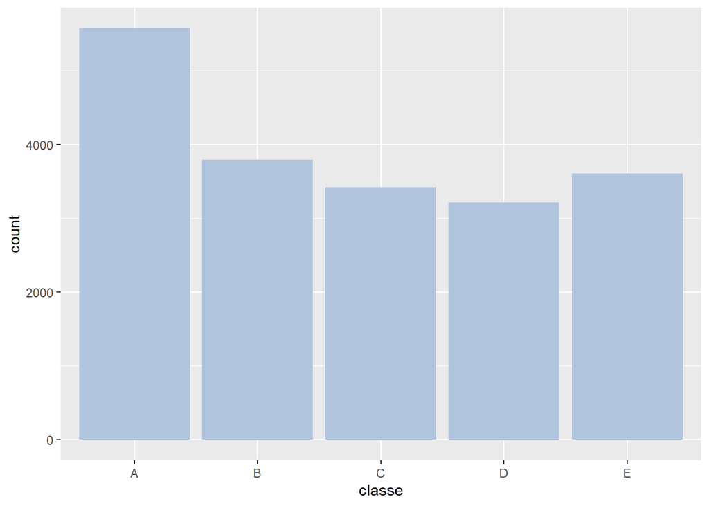

```r
#plotting
ggplot(data=train,aes(x=classe))+geom_bar(fill="lightsteelblue")
```

## Cross validation:

I will separate the train data to a train and a test data to create a model and test in on the 20 subject in the validation data

In order to get out-of-sample errors, split the training data in training (75%) and testing (25%) data) subsets:

```r
set.seed(159)
inTrain<-createDataPartition(y = train$classe,p=0.75,list=F)

training<-train[inTrain,]
testing<- train[-inTrain,]

dim(training) ; dim(testing)
```

```
## [1] 14718    53
```

```
## [1] 4904   53
```

##Model Building:

```r
#random forest model
mod_rf<-randomForest(classe~.,data=training,method="rf")
mod_rf
```

```
##
## Call:
##  randomForest(formula = classe ~ ., data = training, method = "rf")
##                Type of random forest: classification
##                      Number of trees: 500
## No. of variables tried at each split: 7
##
##         OOB estimate of  error rate: 0.46%
## Confusion matrix:
##      A    B    C    D    E  class.error
## A 4182    2    0    0    1 0.0007168459
## B   14 2830    4    0    0 0.0063202247
## C    0   11 2555    1    0 0.0046747176
## D    0    0   24 2386    2 0.0107794362
## E    0    0    2    6 2698 0.0029563932
```

```r
#prediction:
pred_rf<-predict(mod_rf,testing)


#accuracy:

confusionMatrix(testing$classe,pred_rf)
```

```
## Confusion Matrix and Statistics
##
##           Reference
## Prediction    A    B    C    D    E
##          A 1395    0    0    0    0
##          B    3  944    2    0    0
##          C    0    3  852    0    0
##          D    0    0    3  800    1
##          E    0    0    0    2  899
##
## Overall Statistics
##
##                Accuracy : 0.9971
##                  95% CI : (0.9952, 0.9984)
##     No Information Rate : 0.2851
##     P-Value [Acc > NIR] : < 2.2e-16
##
##                   Kappa : 0.9964
##
##  Mcnemar's Test P-Value : NA
##
## Statistics by Class:
##
##                      Class: A Class: B Class: C Class: D Class: E
## Sensitivity            0.9979   0.9968   0.9942   0.9975   0.9989
## Specificity            1.0000   0.9987   0.9993   0.9990   0.9995
## Pos Pred Value         1.0000   0.9947   0.9965   0.9950   0.9978
## Neg Pred Value         0.9991   0.9992   0.9988   0.9995   0.9998
## Prevalence             0.2851   0.1931   0.1748   0.1635   0.1835
## Detection Rate         0.2845   0.1925   0.1737   0.1631   0.1833
## Detection Prevalence   0.2845   0.1935   0.1743   0.1639   0.1837
## Balanced Accuracy      0.9989   0.9978   0.9967   0.9983   0.9992
```

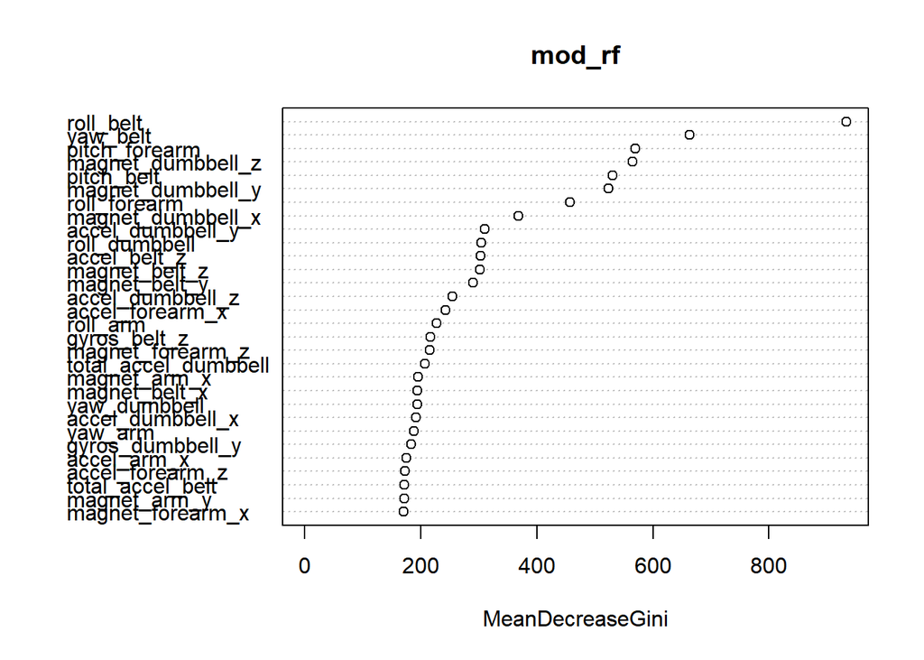

```r
#important variables:
varImpPlot(mod_rf)
```

```r
#classification tree
mod_rpart<-train(classe~.,data=training,method="rpart")
mod_rpart
```

```
## CART
##
## 14718 samples
##    52 predictor
##     5 classes: 'A', 'B', 'C', 'D', 'E'
##
## No pre-processing
## Resampling: Bootstrapped (25 reps)
## Summary of sample sizes: 14718, 14718, 14718, 14718, 14718, 14718, ...
## Resampling results across tuning parameters:
##
##   cp          Accuracy   Kappa
##   0.03702649  0.5006853  0.35037554
##   0.06009684  0.4162208  0.20866419
##   0.11345296  0.3292390  0.06847239
##
## Accuracy was used to select the optimal model using the largest value.
## The final value used for the model was cp = 0.03702649.
```

```r
#prediction
pred_rpart<-predict(mod_rpart,testing)

#accuracy
confusionMatrix(testing$classe,pred_rpart)
```

```
## Confusion Matrix and Statistics
##
##           Reference
## Prediction    A    B    C    D    E
##          A 1272   20   97    0    6
##          B  400  311  238    0    0
##          C  398   25  432    0    0
##          D  376  137  291    0    0
##          E  119  113  241    0  428
##
## Overall Statistics
##
##                Accuracy : 0.4982
##                  95% CI : (0.4841, 0.5123)
##     No Information Rate : 0.523
##     P-Value [Acc > NIR] : 0.9998
##
##                   Kappa : 0.3439
##
##  Mcnemar's Test P-Value : NA
##
## Statistics by Class:
##
##                      Class: A Class: B Class: C Class: D Class: E
## Sensitivity            0.4959  0.51320  0.33256       NA  0.98618
## Specificity            0.9474  0.85156  0.88266   0.8361  0.89418
## Pos Pred Value         0.9118  0.32771  0.50526       NA  0.47503
## Neg Pred Value         0.6315  0.92541  0.78587       NA  0.99850
## Prevalence             0.5230  0.12357  0.26489   0.0000  0.08850
## Detection Rate         0.2594  0.06342  0.08809   0.0000  0.08728
## Detection Prevalence   0.2845  0.19352  0.17435   0.1639  0.18373
## Balanced Accuracy      0.7217  0.68238  0.60761       NA  0.94018
```

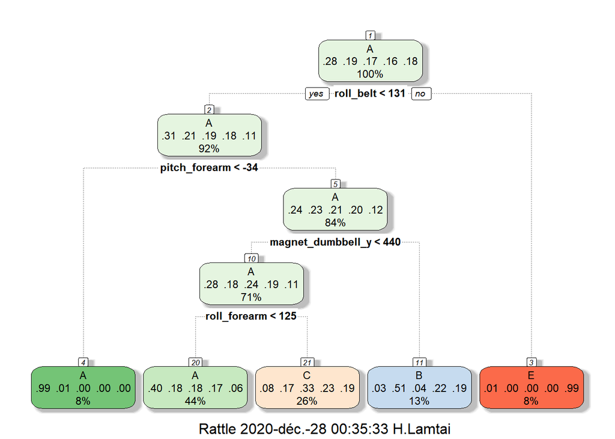

```r
#PLOTTING
fancyRpartPlot(mod_rpart$finalModel)
```

```r
forest<-confusionMatrix(testing$classe,pred_rf)$overall['Accuracy']
tree<-confusionMatrix(testing$classe,pred_rpart)$overall['Accuracy']

cbind(forest,tree)
```

```
##             forest      tree
## Accuracy 0.9971452 0.4981648
```

So I will work with the **random forest** model

[output not shown]

## Prediting on validation set(20 subjects):

```r
predict(mod_rf,valid)
```

```
##  1  2  3  4  5  6  7  8  9 10 11 12 13 14 15 16 17 18 19 20
##  B  A  B  A  A  E  D  B  A  A  B  C  B  A  E  E  A  B  B  B
## Levels: A B C D E
```

##Conclusion:

In this training model I compared **TWO MACHINE LEARNING** methods the random forest and the classification tree and I choose the best accuracy model because i wanted to make prediction on a new data set.

However the training speed for the forest model is slow and its algorithm is not easy to explain but its true power is in the high accuracy.